# Heart Disease

[figure not shown]

## Introduction

Heart disease, also known as cardiovascular disease, is a disorder characterized by clogged blood vessels that can result in a heart attack. According to the World Health Organization, heart disease has been the greatest killer among diseases worldwide over the past 20 years. Every year, heart diseases have caused an estimated 17.9 million mortalities globally. It now accounts for 16% of total mortalities from all causes.

Hence, it is essential to be knowledgeable about the symptoms and factors of heart disease as it is a major public health concern. By analyzing the healthcare data, we can gain profound insights into the disease. We can also use predictive modeling to predict the diagnosis, which may assist in the early detection and prevention of heart disease.

Risk factors of heart disease fall into three main categories:

1. Unchangeable - Age, gender, heredity
2. Modifiable - Smoking, blood cholesterol, blood pressure, obesity, diabetes
3. Contributing - Stress, alcohol, diet and nutrition

## Data Dictionary

The dataset used in this study is the [Statlog (Heart) dataset from UCI Machine Learning Repository](https://archive.ics.uci.edu/ml/datasets/Statlog+%28Heart%29). The following table describes the 14 variables in the dataset.

| No. | Names | Description | Measurement |
| --- | --- | --- | --- |
| 1 | age | Age | in years |
| 2 | sex | Sex | 0 = female, 1 = male |
| 3 | cp | Chest pain type | 1 = typical angina, 2 = atypical angina, 3 = non-anginal pain, 4 = asymptomatic |
| 4 | restbp | Resting blood pressure | in mm Hg |
| 5 | chol | Serum cholesterol | in mg/dl |
| 6 | fbs | Fasting blood sugar > 120 mg/dl | 0 = false, 1 = true |
| 7 | ecg | Resting electrocardiographic results | 0 = normal, 1 = ST-T wave abnormality, 2 = left ventricular hypertrophy |
| 8 | hrate | Max heart rate achieved | integer |
| 9 | exang | Exercise induced angina | 0 = no, 1 = yes |
| 10 | stdep | ST depression induced by exercise relative to rest | integer or float |
| 11 | slope | The slope of the peak exercise ST segment | 1 = upsloping, 2 = flat, 3 = downsloping |
| 12 | fluor | Number of major vessels colored by fluoroscopy | 0 - 3 |
| 13 | thal | Thallium stress test results | 3 = normal, 6 = fixed, 7 = reversible |
| 14 | target | Diagnosis of heart disease | 1 = absent, 2 = present |

The variables include:

- Risk factors - Age, sex, blood pressure, cholesterol, blood sugar
- Symptoms - Chest pain, exercise-induced angina
- Test results - Resting electrocardiography, max heart rate, ST depression, ST segment, fluoroscopy, thallium stress test
- Target variable - Diagnosis of heart disease

## Import Statement

```r
library(tidyverse)
library(gridExtra)
library(cowplot)
library(tree)
```

```r
url <- "https://archive.ics.uci.edu/ml/machine-learning-databases/statlog/heart/heart.dat"

heart <- read.table(url, header = FALSE,
                    col.names = c("age", "sex", "cp", "restbp", "chol",
                                  "fbs", "ecg", "hrate", "exang", "stdep",
                                  "slope", "fluor", "thal", "target"))
```

```r
heart$sex <- as.factor(heart$sex)
heart$cp <- as.factor(heart$cp)
heart$fbs <- as.factor(heart$fbs)
heart$ecg <- as.factor(heart$ecg)
heart$exang <- as.factor(heart$exang)
heart$slope <- as.factor(heart$slope)
heart$fluor <- as.factor(heart$fluor)
heart$thal <- as.factor(heart$thal)
heart$target <- as.factor(heart$target)
```

```r
levels(heart$sex) <- c("Female","Male")
levels(heart$cp) <- c("Typical","Atypical","Non-anginal","Asymptomatic")
levels(heart$fbs) <- c("False","True")
levels(heart$ecg) <- c("Normal","ST-T wave abnormality","Left Ventricular Hypertrophy")
levels(heart$exang) <- c("No","Yes")
levels(heart$slope) <- c("Upsloping","Flat","Downsloping")
levels(heart$thal) <- c("Normal","Fixed defect","Reversible defect")
levels(heart$target) <- c("Absent","Present")
```

```r
attach(heart)
```

## Exploratory Data Analysis

### I. Which gender has a higher risk of heart disease?

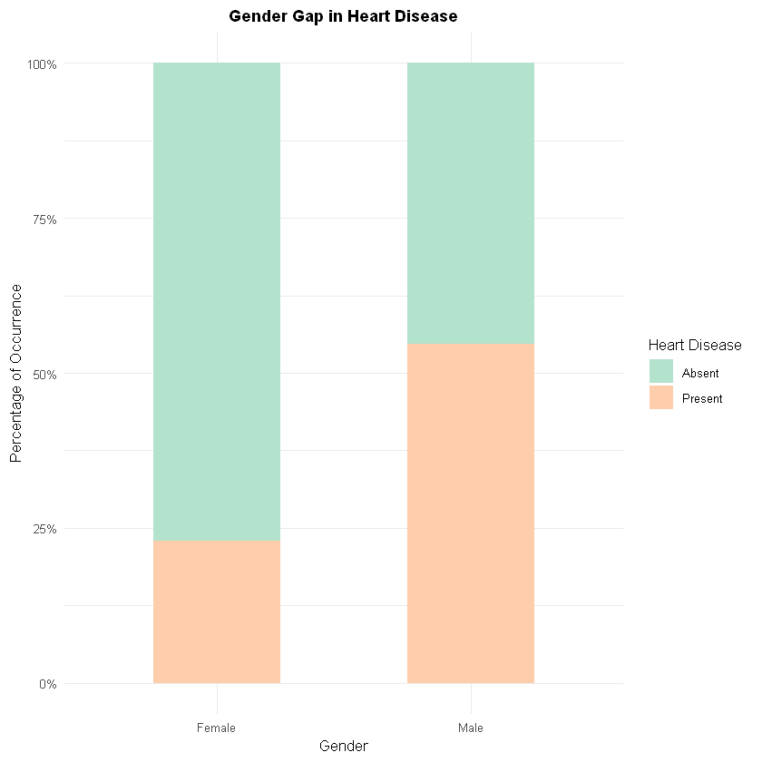

```r
ggplot(heart, aes(x=sex, y=1, fill=target)) +
  geom_bar(stat="identity", position="fill", width=.5) +
  scale_y_continuous(labels = scales::percent) +
  scale_fill_brewer(palette = "Pastel2") +
  labs(x="Gender", y = "Percentage of Occurrence",
       fill = "Heart Disease", title="Gender Gap in Heart Disease") +
  theme_minimal() +
  theme(text = element_text(size=10),
        plot.title = element_text(hjust = 0.5, size=11, face = "bold"))
```

Among female respondents, less than a quarter of them are diagnosed with heart disease. Contrarily, heart disease is present in more than half of the male respondents. Hence, it can be said that male has a higher risk than female.

Due to men’s higher absolute risk relative to women, cardiovascular disease has been seen as a male disease for a long time. There are a variety of reasons that can explain the gender difference in heart disease. For instance, psychosocial and behavioral factors such as excessive alcohol consumption and smoking, are in favor of women.

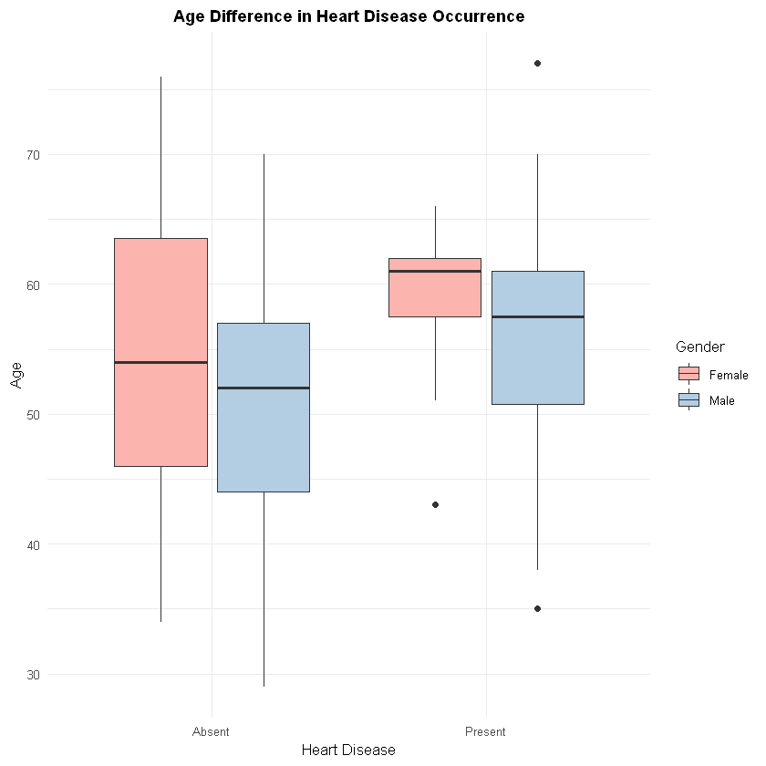

```r
ggplot(heart, aes(x=target, y=age)) +
  geom_boxplot(aes(fill = factor(sex))) +
  scale_fill_brewer(palette = "Pastel1")+
  labs(x="Heart Disease", y="Age", fill = "Gender",
       title="Age Difference in Heart Disease Occurrence") +
  theme_minimal() +
  theme(text = element_text(size=10),
        plot.title = element_text(hjust = 0.5, size=11, face = "bold"))
```

There is an age gap between genders in terms of heart disease diagnosis. The interquartile range for men with heart disease is much larger than their female counterparts. The boxplot for female with heart disease is also heavily left-skewed in comparison with the male’s, indicating that female respondents with heart disease get it later in their life.

A study in 2010 has revealed that cardiovascular disease develops 7 to 10 years later in women than in men. In spite of that, it remains the leading cause of mortality in women. Heart attack can be more fatal in women. Due to women's smaller body size and blood vessels, blockages of the same size can be more serious. The narrower vessel channel also makes surgery and angioplasty procedures more complicated. Hence, the risk should not be underestimated due to the false sense of security that females are protected against cardiovascular disease.

### II. What is the relationship between heart rate and age?

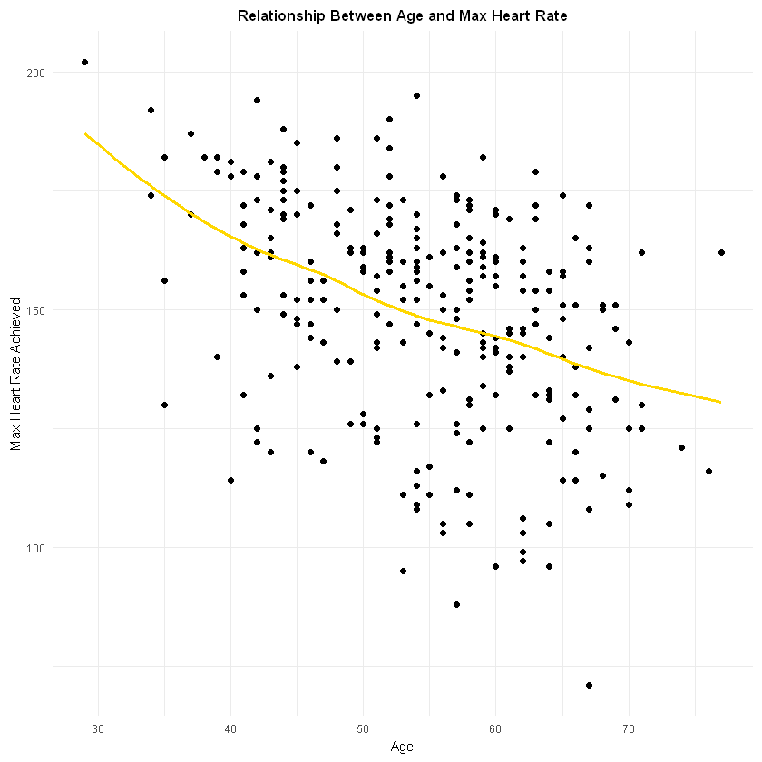

```r
ggplot(heart, aes(x=age, y=hrate)) +
  geom_point() +
  geom_smooth(colour="gold", se=FALSE) +
  labs(x="Age", y = "Max Heart Rate Achieved",
       title="Relationship Between Age and Max Heart Rate") +
  theme_minimal() +
  theme(text = element_text(size=9),
        plot.title = element_text(hjust = 0.5, size=10, face = "bold"))
```

It shows that age and maximum heart rate are inversely related. Many studies have shown that the maximum heart rate declines with age. The major reason behind the age-related decrease is due to a drop in the intrinsic heart rate. This implies that the heart’s own pacemaker (a cluster of cells responsible for initiating each heartbeat) has lost its functional efficiency.

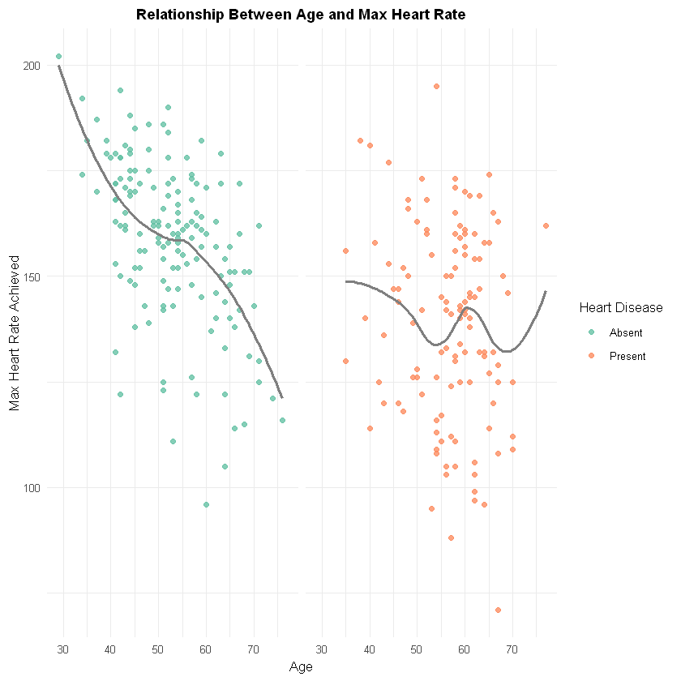

```r
ggplot(heart, aes(x=age, y=hrate)) +
  geom_point(aes(colour=target), alpha = 0.8) +
  geom_smooth(colour="grey50", se=FALSE) +
  labs(x="Age", y = "Max Heart Rate Achieved",
       title="Relationship Between Age and Max Heart Rate") +
  scale_colour_brewer(name="Heart Disease", palette="Set2") +
  facet_wrap(~target) +
  theme_minimal() +
  theme(strip.background=element_blank(),
        strip.text=element_blank(),
        text = element_text(size=10),
        plot.title = element_text(hjust = 0.5, size=11, face = "bold"))
```

The graph prior to this shows that the maximum heart rate decreases steadily with age. However, after splitting the graph based on the diagnosis of heart disease, this statement no longer holds true for those who suffered from heart disease.

The graph for those with heart disease has a more irregular pattern. It also shows that those who suffered from heart disease have a lower maximum heart rate at an earlier age, reflecting poor heart functionality. Hence, an abnormally low maximum heart rate may be used as a risk marker for younger people to detect heart disease.

### III. Which type of chest pain is the most prevalent in individuals with heart disease?

The type of chest pain contains 4 different levels:

1. Typical angina - caused by physical exertion or emotional stress
2. Atypical angina - does not cause any typical chest pain but will radiate to other parts of the body
3. Non-anginal pain - resembles heart discomfort in people who do not have heart disease
4. Asymptomatic - showing no symptoms or minimal symptoms

Note: Angina is described as a kind of discomfort caused when the heart doesn’t get enough oxygen-rich blood.

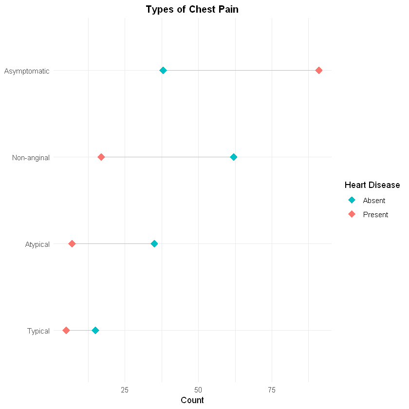

```r
heart %>%
  group_by(target, cp) %>%
  summarize(count=n()) %>%
  ggplot(aes(cp, count)) +
  geom_line(aes(group = cp), alpha=0.2) +
  geom_point(aes(color = target), size=4, shape=18) +
  scale_colour_manual(values=c("#00BFC4","#F8766D")) +
  labs(x=NULL, y="Count", colour="Heart Disease",
       title="Types of Chest Pain") +
  theme_minimal() +
  theme(text = element_text(size=11),
        plot.title = element_text(hjust = 0.5, size=12, face = "bold")) +
  coord_flip()
```

It is evident that the ‘Asymptomatic’ type is the most prevalent among the respondents with heart disease. This means that most of them actually do not show any symptoms of heart disease. A person who appears to be healthy may be experiencing painless damage to the heart. The first sign of silent heart disease can be fatal: a heart attack or even death.

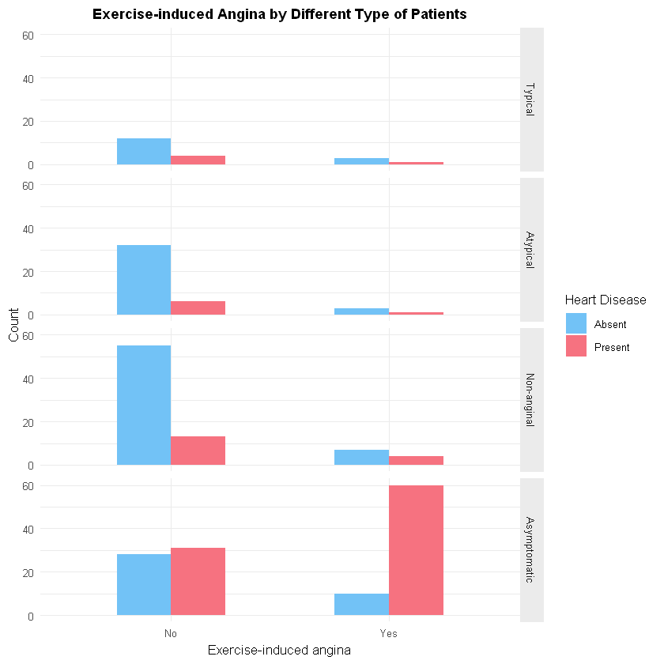

```r
ggplot(heart, aes(x=exang, fill=target)) +
  geom_bar(stat="count", position="dodge", width=.5) +
  scale_fill_manual(values=c("#72c2f6","#F67280")) +
  labs(x="Exercise-induced angina", y = "Count", fill = "Heart Disease",
       title="Exercise-induced Angina by Different Type of Patients") +
  theme_minimal() +
  facet_grid(cp~.) +
  theme(text = element_text(size=10),
        strip.background=element_rect(colour = "grey92", fill = "grey92"),
        plot.title = element_text(hjust = 0.5, size=11, face = "bold"))
```

Exercise-induced angina is found to have a higher occurrence in respondents suffering from heart disease, specifically with those who are otherwise asymptomatic. This means that even if they do not suffer from any chest pain during day-to-day activities, they might still experience some discomfort during physical exercise.

In fact, it was proven that exercise-induced angina is a common complaint among cardiac patients, which can be triggered further when exposed to a cold environment. Thus, this symptom can be served as an indicator of potential heart disease.

### IV. Can thallium stress tests detect heart disease?

A thallium stress test is a nuclear imaging test that evaluates blood flows in the heart. The heart is photographed while doing exercise and at rest. It can provide diagnostic information about patients with known or suspected cardiovascular disease.

Based on the dataset, the test results are categorized as normal, fixed defect and reversible defect. Fixed defects refer to abnormalities present on scan both during cardiac stress and at rest. Reversible defects are those that are present on the post-stress scan but show improvement in the resting scan.

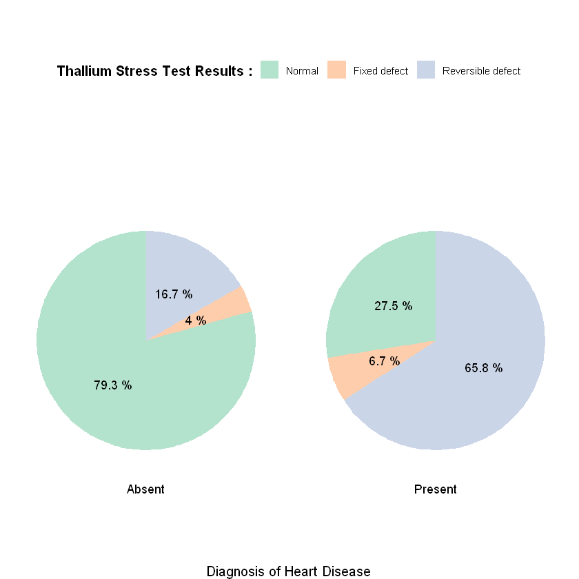

```r
thal1 <- heart %>% group_by(thal) %>%
  filter(target %in% "Absent") %>%
  count() %>% ungroup() %>%
  mutate(pct=`n`/sum(`n`)) %>%
  ggplot(aes(x="", y=n, fill=factor(thal))) +
  geom_bar(stat="identity", width=1) +
  coord_polar("y", start=0) +
  labs(x=NULL, y = "Absent", fill = "Thallium Stress Test Results :") +
  scale_fill_brewer(palette = "Pastel2") +
  theme_classic() +
  theme(axis.line = element_blank(), axis.text = element_blank(),
        axis.ticks = element_blank(), legend.direction = "horizontal",
        legend.position = "top", legend.box = "horizontal",
        legend.title = element_text(size=12, face="bold")) +
  geom_text(aes(label =paste(round(pct*100,1),"%")), position =position_stack(vjust=0.5))

thal2 <- heart %>% group_by(thal) %>%
  filter(target %in% "Present") %>%
  count() %>% ungroup() %>%
  mutate(pct=`n`/sum(`n`)) %>%
  ggplot(aes(x="", y=n, fill=factor(thal))) +
  geom_bar(stat="identity", width=1) +
  coord_polar("y", start=0) +
  labs(x=NULL, y = "Present") +
  scale_fill_brewer(palette = "Pastel2") +
  theme_classic() +
  theme(axis.line = element_blank(), axis.text = element_blank(),
        axis.ticks = element_blank(), legend.position = "none") +
  geom_text(aes(label=paste(round(pct*100,1),"%")), position=position_stack(vjust=0.5))

legend <- get_legend(thal1)
thal1 <- thal1 + theme(legend.position="none")

grid.arrange(legend, thal1, thal2, ncol=2, heights=c(1/4,3/4),
             layout_matrix=rbind(c(1,1), c(2,3)),
             bottom = grid::textGrob("Diagnosis of Heart Disease",
                                     vjust = 0.6, hjust = 0.5))
```

Almost 80% of respondents without heart disease have normal test results. On the other hand, 66% of respondents with heart disease have reversible defects. Thus, it demonstrates that thallium stress test can be quite effective in detecting heart disease and the results may contribute to the prediction of diagnosis.

Nonetheless, normal results still account for more than a quarter of the respondents with heart disease. Hence, the risk should not be underestimated even with normal stress test results.

### V. How does the ST segment differ between individuals with and without heart disease?

Electrocardiogram (ECG) measures electrical activities of the heart. The ST segment reflects the period of zero potential between ventricular depolarization and repolarization. The ST segment can be displaced upwards (elevation) or downwards (depression).

ST depression refers to an ECG result in which the trace in the ST segment is unusually low. The acceptable level of ST segment depression is less than 0.5mm, while reading that is more than 0.5mm is considered pathological.

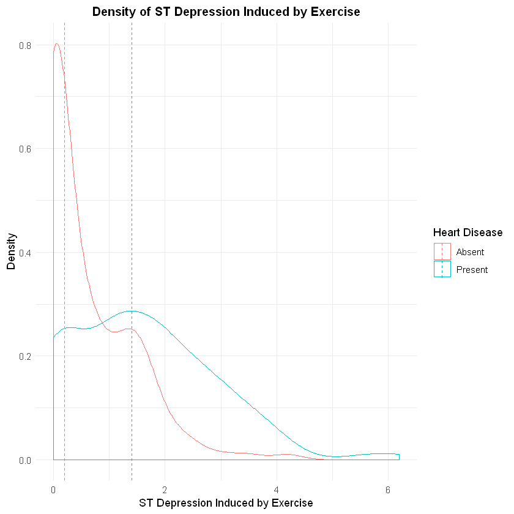

```r
heart %>%
  group_by(target) %>%
  mutate(mid = median(stdep))  %>%
  ggplot(aes(x=stdep, color=target)) +
  geom_density()+
  geom_vline(aes(xintercept=mid, color=target),
             linetype="dashed") +
  labs(x="ST Depression Induced by Exercise", y = "Density",
       colour = "Heart Disease",
       title="Density of ST Depression Induced by Exercise") +
  theme_minimal() +
  theme(text = element_text(size=11),
        plot.title = element_text(hjust = 0.5, size=12, face = "bold"))
```

The graph supports that higher ST depression is related to the presence of heart disease. It can be seen that the dashed line that represents the median is higher for patients with heart disease than non-diseased patients.

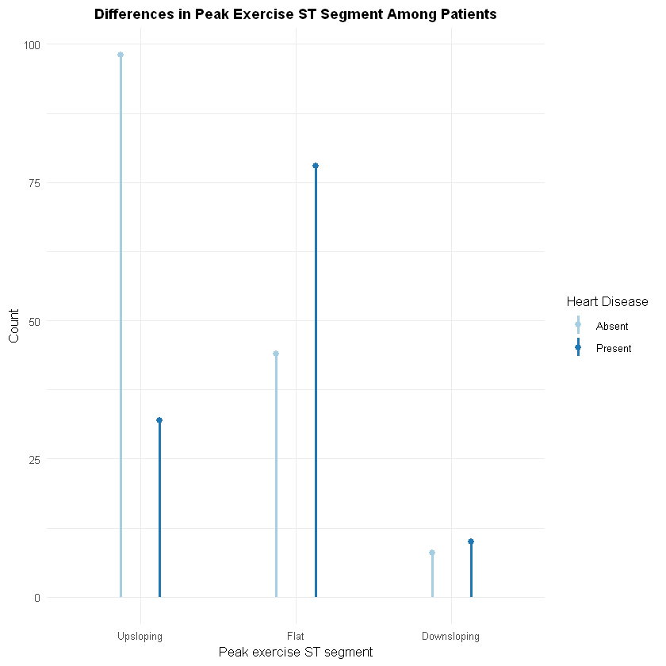

```r
heart %>%
  group_by(target, slope) %>%
  summarize(n=n()) %>%
  ggplot(aes(ymin=0, ymax=n, x=factor(slope), colour=target)) +
  geom_linerange(position=position_dodge(width=.5), size=1) +
  geom_point(aes(y=n),
             position=position_dodge(width=.5), size=2, shape=19) +
  labs(x="Peak exercise ST segment", y="Count", colour="Heart Disease",
       title="Differences in Peak Exercise ST Segment Among Patients") +
  theme_minimal() +
  scale_colour_brewer(palette="Paired") +
  theme(text = element_text(size=10),
        plot.title = element_text(hjust = 0.5, size=11, face = "bold"))
```

Besides the reading of ST depression, the characteristic of ST segment is also important. As shown above, respondents who are not diagnosed with heart disease have the highest rate of showcasing an upsloping ST segment during exercise, followed by a flat one.

On the flip side, those with heart disease are more likely to exhibit a flat ST segment. Previous studies have proved that the normal ST segment during exercise has an upward curve. Flat or downsloping ST segments might indicate possible abnormalities.

## Predictive Modeling

A decision tree is a predictive model which can be used to represent both classifiers and regression models. In this study, classification trees are used to classify the diagnosis of heart disease into a predefined set of classes (absent/present) based on their attribute values (e.g., age, gender, chest pain type, etc).

### Classification Tree

```r
set.seed(2)
training <-  sample(1:nrow(heart), nrow(heart)/2)
testing <- heart[-training, ]
target.test <- target[-training]
```

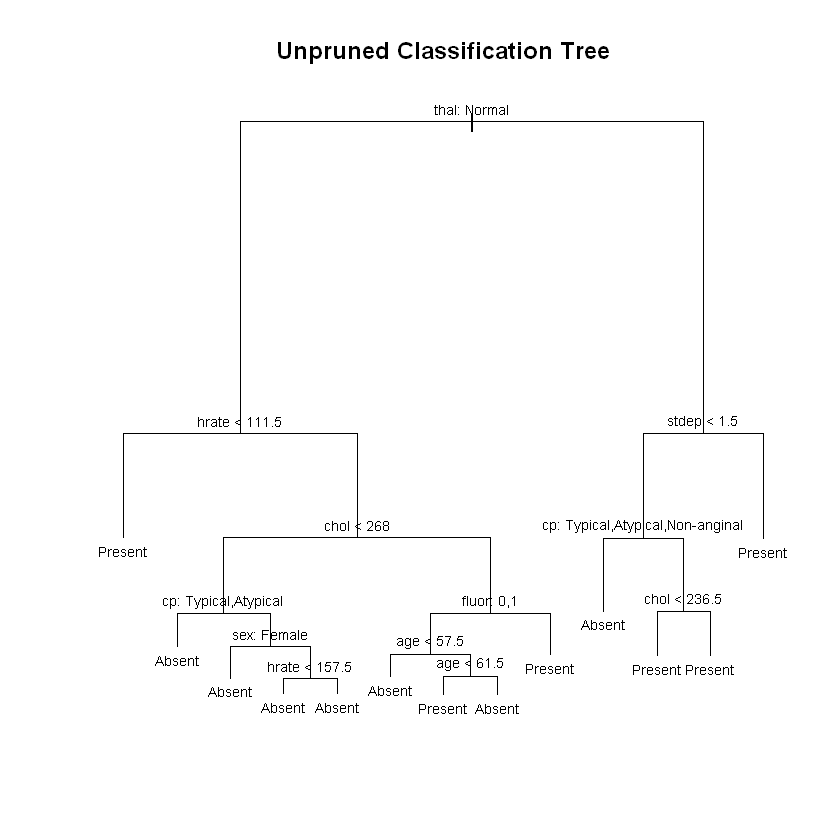

```r
tree.heart  <- tree(target~., heart, subset=training)

plot(tree.heart)
text(tree.heart, pretty=0,cex=0.7)
title(main = "Unpruned Classification Tree")
```

```r
summary(tree.heart)
```

```
Classification tree:
tree(formula = target ~ ., data = heart, subset = training)
Variables actually used in tree construction:
[1] "thal"  "hrate" "chol"  "cp"    "sex"   "fluor" "age"   "stdep"
Number of terminal nodes:  13
Residual mean deviance:  0.5484 = 66.9 / 122
Misclassification error rate: 0.1185 = 16 / 135
```

By fitting the classification tree using all of the predictors, the tree turned out to be quite complicated (i.e., has too many nodes), reducing the usefulness of its straightforward graphical representation. Branches that are not contributing to the generalization accuracy can be trimmed to simplify the interpretation of the hierarchical structure and improve its comprehensibility. This process is called pruning.

The summary shows that the tree has **13 terminal nodes** and a **misclassification error rate of 11.85%**. 8 out of 13 predictors have been used in the tree construction. By evaluating the tree model using the test set, the unpruned tree has an **accuracy rate of 74.81%**.

### Pruning

Cross-validation and cost complexity pruning is utilized to determine the optimal level of tree complexity. The misclassification error rate is used as the cost function to guide the pruning process.

```r
set.seed(3)
cv.heart <- cv.tree(tree.heart, FUN=prune.misclass)
cv.heart
```

```
$size
[1] 13  9  7  3  2  1

$dev
[1] 41 41 38 41 43 75

$k
[1] -Inf    0    1    2    5   35

$method
[1] "misclass"

attr(,"class")
[1] "prune"         "tree.sequence"
```

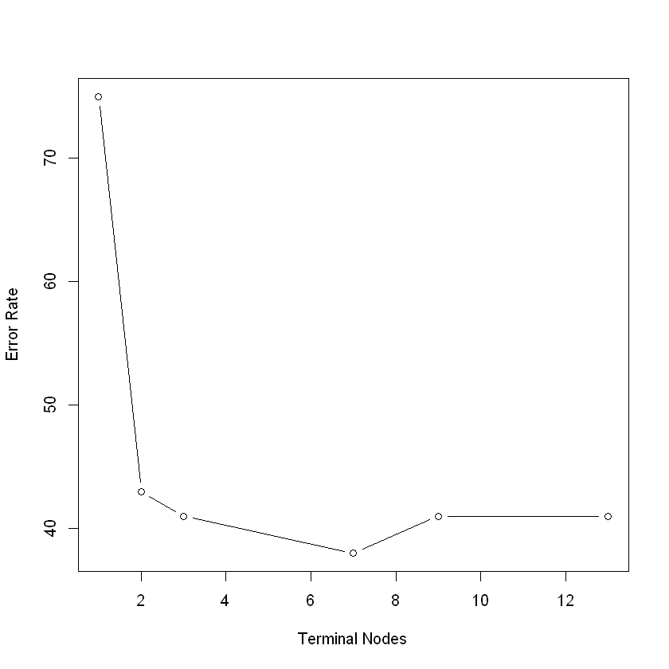

```r
plot(cv.heart$size, cv.heart$dev, type="b",
     xlab="Terminal Nodes", ylab="Error Rate")
```

The cross-validation of terminal nodes amount and the corresponding error rate shows that a tree with **7 terminal nodes** will result in the lowest misclassification error rate.

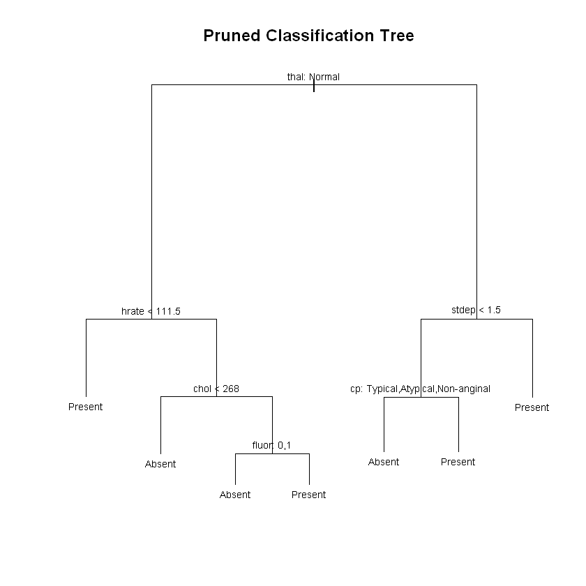

```r
prune.heart <- prune.misclass(tree.heart, best=7)
plot(prune.heart)
text(prune.heart, pretty=0,cex=0.7)
title(main = "Pruned Classification Tree")
```

```r
summary(prune.heart)
```

```
Classification tree:
snip.tree(tree = tree.heart, nodes = c(10L, 13L, 22L))
Variables actually used in tree construction:
[1] "thal"  "hrate" "chol"  "fluor" "stdep" "cp"
Number of terminal nodes:  7
Residual mean deviance:  0.6988 = 89.45 / 128
Misclassification error rate: 0.1333 = 18 / 135
```

```r
prune.heart
```

```
node), split, n, deviance, yval, (yprob)
      * denotes terminal node

 1) root 135 187.100 Present ( 0.48889 0.51111 )
   2) thal: Normal 75  86.990 Absent ( 0.73333 0.26667 )
     4) hrate < 111.5 5   0.000 Present ( 0.00000 1.00000 ) *
     5) hrate > 111.5 70  72.740 Absent ( 0.78571 0.21429 )
      10) chol < 268 44  26.810 Absent ( 0.90909 0.09091 ) *
      11) chol > 268 26  35.430 Absent ( 0.57692 0.42308 )
        22) fluor: 0,1 20  24.430 Absent ( 0.70000 0.30000 ) *
        23) fluor: 2,3 6   5.407 Present ( 0.16667 0.83333 ) *
   3) thal: Fixed defect,Reversible defect 60  57.170 Present ( 0.18333 0.81667 )
     6) stdep < 1.5 34  42.810 Present ( 0.32353 0.67647 )
      12) cp: Typical,Atypical,Non-anginal 12  15.280 Absent ( 0.66667 0.33333 ) *
      13) cp: Asymptomatic 22  17.530 Present ( 0.13636 0.86364 ) *
     7) stdep > 1.5 26   0.000 Present ( 0.00000 1.00000 ) *
```

The above shows that thal (thallium stress test) is the root node, which is the best attribute to predict outcomes. It then splits into the decision nodes according to the rules. If it obeys the rule, it will go down to the left child node and to the right if it doesn’t (e.g. if the test result is normal, it will go to the node with heart rate < 111.5; if the test result is not normal, it will go to the node with ST depression < 1.5). This will carry on until it reaches one of the seven terminal nodes.

The summary shows that the tree now has **7 terminal nodes** and a **misclassification error rate of 13.33%**. Only 6 of the predictors have been used to construct the pruned tree. The pruned tree has a **prediction accuracy rate of 76.29%**, which is a slight improvement from the unpruned tree.

### Comparison of Pruned and Unpruned Classification Trees

```r
# unprune accuracy
tree.pred <- predict(tree.heart, testing, type = "class")
table(tree.pred, target.test)
mean(tree.pred==target.test)
```

```
         target.test
tree.pred Absent Present
  Absent      67      17
  Present     17      34
```

0.748148148148148

```r
# prune accuracy
prune.pred=predict(prune.heart, testing, type="class")
table(prune.pred, target.test)
mean(prune.pred==target.test)
```

```
          target.test
prune.pred Absent Present
   Absent      69      17
   Present     15      34
```

0.762962962962963

|  | Unpruned | Pruned |
| --- | --- | --- |
| No. of Terminal Nodes | 13 | 7 |
| Predictors Used | 8 | 6 |
| Accuracy Rate | 74.81% | 76.29% |
| Misclassification Rate | 11.85% | 13.33% |

Comparing both trees, the **pruned tree** has only 7 terminal nodes, which makes the classification process **more simplified** than the unpruned tree with 13 terminal nodes. The pruned tree only used 6 out of the 13 predictors. In contrast, 8 predictors were fit into the unpruned tree.

The **diagnostic accuracy has increased** around 1.5% after pruning. However, the **misclassification rate had also gone up** at the same rate. Pruning a tree will increase the misclassification error rate of training data, but should decrease the error rate on independent test data. This is because in high uncertainty domains, all but the first two or three levels of the tree were being removed. Users should choose the appropriate tree based on their criteria.

## Conclusion

In conclusion, men have higher odds of developing heart disease than women. Nevertheless, women should not take this lightly as heart disease remains the biggest cause of death among women. We also found out that younger people with heart disease have abnormally low maximum heart rates, whereas the heart rate of those without heart disease decreases steadily with age.

Despite technological advancements and increased health consciousness, heart diseases still claim millions of lives every year. Excruciatingly, this catastrophic event can occur without any warning. The analysis shows that most patients with heart disease do not suffer from chest pain. However, exercise-induced angina is found to be more common in cardiac patients. A thallium stress test seems to be effective in detecting heart disease. In spite of that, a normal test result does not equate to risk-free as it still accounts for more than a quarter of those suffering from heart disease.

There are also other means of measure that can be employed to detect heart disease. For example, the ST segment in electrocardiogram (ECG) can be used to monitor the risk. A high number of ST depression or a flat ST segment during exercise might indicate the presence of heart disease. The susceptibility to heart disease can also be estimated with the help of predictive modeling. In this study, decision tree was used to predict the diagnosis of heart disease.

Many factors play a part in our heart health, but not all of them can be altered. Preventive measures and early diagnosis need to be emphasized, especially towards high-risk subjects. Genetics can’t be altered, but diets and everyday habits sure do. Regardless of one’s genetic profile, lifestyle factors may reduce the risk of heart disease.